# Miscelaneous Tips

Alan T. Arnholt

Last compiled: Sunday, February 12, 2017 - 14:12:18.

# 1 Using $\LaTeX$

- Start and end inline mathematics with one `$`
- Start and end displayed mathematics with two `$$`
- For more complex environments, [click here.](https://en.wikibooks.org/wiki/LaTeX/Advanced_Mathematics)
- [Symbol table](http://mirror.jmu.edu/pub/CTAN/info/examples/Math_into_LaTeX-4/SymbolTables.pdf)
- To bold mathematics, use `\mathbf{}`. For example, to bold $\Sigma$ use `\mathbf{\Sigma}` $\rightarrow \mathbf{\Sigma}$
- To create a superscript with text, use `^{\text{Your text}}`. For example, to write the $i^{\text{th}}$ example use `$i^{\text{th}}$`.

# 2 Labeling Equations with `bookdown`

> Equation labels must start with the prefix `eq:` in `bookdown`. All labels in `bookdown` must only contain alphanumeric characters, `:`, `-`, and/or `/`. Equation references work best for LaTeX/PDF output, and they are not well supported in Word output or e-books. For HTML output, `bookdown` can only number the equations with labels. Please make sure equations without labels are not numbered by either using the `equation*` environment or adding `\nonumber` or `\notag` to your equations. The same rules apply to other math environments, such as `eqnarray`, `gather`, `align`, and so on (e.g., you can use the `align*` environment).

To create Equation (2.1), use the code shown in the gray box below.

$$\begin{equation}
f(x)=(x+a)(x+b)
\tag{2.1}
\end{equation}$$

```r
\begin{equation}
 f(x)=(x+a)(x+b)
 (\#eq:label1)
\end{equation}
```

To refer to Equation (2.1), use `\@ref(eq:label1)`.

To create the aligned Equation (2.2), use the code shown in the gray box below.

$$\begin{align}
f(x) &= x^4 + 7x^3 + 2x^2 \nonumber \\
&\qquad {} + 10x + 12
\tag{2.2}
\end{align}$$

```r
\begin{align}
 f(x) &= x^4 + 7x^3 + 2x^2 \nonumber \\
      &\qquad {} + 10x + 12
(\#eq:aligned)
\end{align}
```

To write the piecewise function in Equation (2.3), use the code shown in the gray box below.

$$\begin{equation}
u(x) =
\begin{cases}
\exp{x} & \text{if } x \geq 0 \\
1 & \text{if } x < 0
\end{cases}
\tag{2.3}
\end{equation}$$

```r
\begin{equation}
 u(x) =
  \begin{cases}
   \exp{x} & \text{if } x \geq 0 \\
   1       & \text{if } x < 0
  \end{cases}
  (\#eq:piece)
\end{equation}
```

# 3 Labeling Graphs with `bookdown`

Figure 3.1 was created using the `R` code chunk and code below. Note that to refer to Figure 3.1, the name of the code chunk label is used. In this case, the code chunk label is `HISTO` and to refer to Figure 3.1 one uses the syntax `\@ref(fig:HISTO)`.

````
```{r, label = "HISTO", fig.cap = "Write your descriptive caption here", echo = FALSE}
set.seed(13)
stuff <- rnorm(1000, 100, 15)
hist(stuff, col = "pink", breaks = "Scott")
```
````

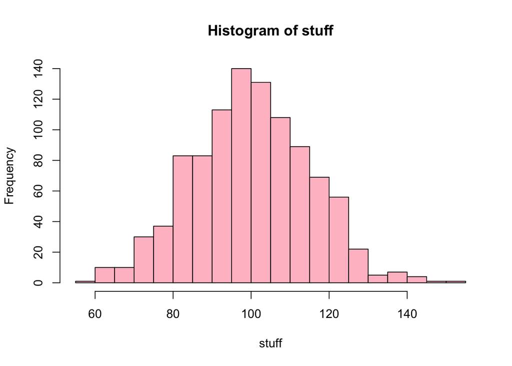

Figure 3.1: Write your descriptive caption here

# 4 Labeling Tables with `bookdown`

Table 4.1 was created using the `R` code chunk and code below. Note that to refer to Table 4.1, the name of the code chunk label is used. In this case, the code chunk label is `FT` and to refer to Table 4.1 one uses the syntax `\@ref(tab:FT)`.

````
```{r, label = "FT", echo = FALSE}
knitr::kable(head(iris), booktabs = TRUE,
caption = 'The first six rows of `iris`'
)
```
````

Table 4.1: The first six rows of `iris`

| Sepal.Length | Sepal.Width | Petal.Length | Petal.Width | Species |
| --- | --- | --- | --- | --- |
| 5.1 | 3.5 | 1.4 | 0.2 | setosa |
| 4.9 | 3.0 | 1.4 | 0.2 | setosa |
| 4.7 | 3.2 | 1.3 | 0.2 | setosa |
| 4.6 | 3.1 | 1.5 | 0.2 | setosa |
| 5.0 | 3.6 | 1.4 | 0.2 | setosa |
| 5.4 | 3.9 | 1.7 | 0.4 | setosa |